# QTM 151 - Quiz 1

## Quiz is open 11:30am to 12:20pm

Print your name below

```python
# Write your answer here

print("James Tsai")
```

```
James Tsai
```

This quiz is open book

- You can use the lecture notes
- You will get partial credit for attempting the questions
- To get full credit, the code should work as intended
- You should NOT communicate with other students

Print the following message:

"I will abide by Emory's code of conduct"

```python
# Write your answer here:

print("I will abide by Emory's code of conduct")
```

```
I will abide by Emory's code of conduct
```

Import the libraries "numpy", "matplotlib.pyplot", and "pandas"

```python
import numpy as np
import matplotlib.pyplot as plt
import pandas as pd
```

1. IF/ELIF/ELSE statements
- In the beginning of the code cell below, two lists are created, where element 0 is one of two random choices:

```
list_p = ["Introduction"/"Intro", "to", "Python"]
list_r = ["Introduction"/"Intro", "to", "R"]
```

- Create a new variable `keyword = "Introduction"`
- Create an if/elif/else block that tests whether `keyword` is part of either  
  list. Depending on the outcome (belongs to list_p, belongs to list_r, doesn't belong to either list) print an appropriate message to the screen.

HINT: If the creation of list_p and list_r is confusing, add print statements to view the two lists and run the cell 3-4 times to see some of the possible situations

```python
### create lists DO NOT CHANGE
str_choices = [["Introduction", "Intro"], ["Intro", "Introduction"], ["Intro", "Intro"]]
str_indices = np.random.choice([0, 1, 2])
start_str = str_choices[str_indices]

list_p = [start_str[0], "to", "Python"]
list_r = [start_str[1], "to", "R"]

### Your solution below
keyword = "Introduction"

if keyword in list_p:
    print(f"{keyword} belongs to list_p")
elif keyword in list_r:
    print(f"{keyword} belongs to list_r")
else:
    print(f"{keyword} doesn't belong to either list")

# checking answers
print()
```

```
Introduction belongs to list_p
```

2. Generate a vector of values and plot it
- Below, two lists are defined containing values of $x_k$ and $y_k$

```
    coord_x = [1,4, 0, -1, 20, 40]
    coord_y = [2,2, 0, 10, 0, 1]
```

- Create a vector (**vector always means numpy array**) `hypotenuse_sqr` with elements $h_k$ defined by the formula

$\qquad h_k = x_k^2 + y_k^2$

- You **should not** define it manually: so "hypoteneuse_sqr = np.array([5, 20, 0, 101, 400, 1601])" is not an acceptable answer
- Produce a **histogram** with the elements of `hypotenuse_sqr` on the horizontal axis
- Label the axes and the title
- Change the color to "orange", "green" or "purple" (you choose)
- Make sure the plot appears in an output cell

Hint: Most mathematical operations are defined for Numpy arrays, which allows you to avoid loops

Hint: type "help(plt.hist)" to see which argument is used to change color

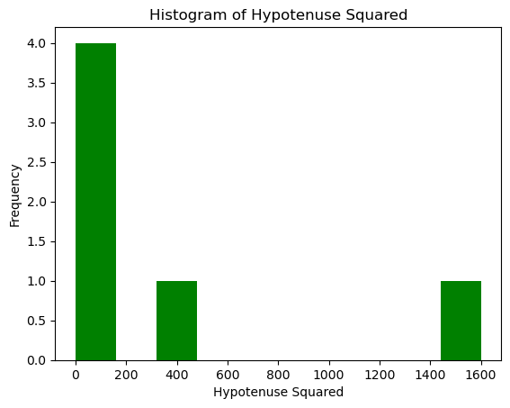

```python
coord_x = [1,4, 0, -1, 20, 40]
coord_y = [2,2, 0, 10, 0, 1]

### Your solution below

coord_x = np.array(coord_x)
coord_y = np.array(coord_y)
hypotenuse_sqr = coord_x**2 + coord_y**2
plt.hist(hypotenuse_sqr, color='green')
plt.xlabel('Hypotenuse Squared')
plt.ylabel('Frequency')
plt.title('Histogram of Hypotenuse Squared')
plt.show()
```

3. Histograms of random variables
- Let $n = 500$
- Generate "vec_x" from a normal distribution with (loc = 0,scale = 1,size = n)
- Generate "vex_z" from a normal distribution with (loc = 5,scale = 1,size = n)
- Plot two **histograms** on a single row using the `plt.subplots` syntax
  - Label the axes and title
  - Each graph should have its axes labeled, and should have their own title

Hint: If you can't remember how subplots works, generate two individual plots for partial credit

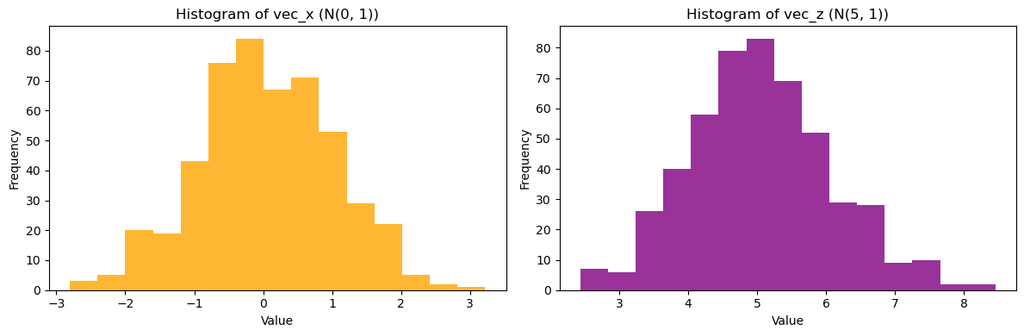

```python
### Your solution below:
n = 500
vec_x = np.random.normal(loc=0, scale=1, size=n)
vec_z = np.random.normal(loc=5, scale=1, size=n)

# Create subplots: 1 row, 2 columns
fig, axes = plt.subplots(1, 2, figsize=(12, 4), tight_layout=True)

axes[0].hist(vec_x, bins=15, color='orange', alpha=0.8) #using bin for tighter visualization
axes[0].set_title('Histogram of vec_x (N(0, 1))')
axes[0].set_xlabel('Value')
axes[0].set_ylabel('Frequency')

axes[1].hist(vec_z, bins=15, color='purple', alpha=0.8)
axes[1].set_title('Histogram of vec_z (N(5, 1))')
axes[1].set_xlabel('Value')
axes[1].set_ylabel('Frequency')

plt.show()
```

4. Combine information across datasets
- Read the dataset "/data_quiz_1/germany_co2_emissions.csv" and store it as "data_germany"
- View the dataset, and see what variables it contains
- Create a **scatter plot** of CO2 emissions with the following characteristics
  - The yearly variable on the x-axis.
  - Germany's CO2 emissions on the y-axis.
  - Label the axes

```
   year  total_emissions
0  1990         955310.0
1  1991         932550.0
2  1992         892820.0
3  1993         887060.0
4  1994         875900.0
```

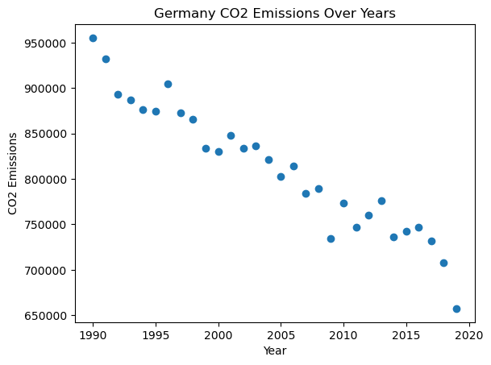

```python
### Your solution below:

data_germany = pd.read_csv("data_quiz_1/germany_co2_emissions.csv")
print(data_germany.head())

plt.scatter(data_germany['year'], data_germany['total_emissions'])
plt.xlabel('Year')
plt.ylabel('CO2 Emissions')
plt.title('Germany CO2 Emissions Over Years')
plt.show()
```

5. Loop through dfferent variables and plot
- Read the dataset "data_quiz_1/wdi_ageprop_2020.csv"
- Create a list of variable names with the following elements:

```
    list_varnames = ["percent_ages0to14","percent_ages15to64"]
```

- Run a for loop that computes the mean for each variable and print it on screen.

Hint: Computing the mean of a column/variable from a Pandas dataset is just like computing the mean of a Numpy array

```python
### Your solution below:
data_age = pd.read_csv("data_quiz_1/wdi_ageprop_2020.csv")
list_varnames = ["percent_ages0to14","percent_ages15to64"]
for var in list_varnames:
    mean_value = data_age[var].mean()
    print(f"Mean of {var}: {mean_value}")
```

```
Mean of percent_ages0to14: 26.90657125728302
Mean of percent_ages15to64: 63.68465159973585
```

6. Run loop through different datasets and compute statistics
- Create a list with the ".csv" dataset names of two countries of your choice. For example

```
    ["data_quiz_1/name1.csv","data_quiz_1/name2.csv"]
```

- Create an empty list called `list_emissions`
- Run a for-loop over the list of dataset names. Inside the loop:
  - Read the corresponding ".csv" dataset.
  - Compute the mean of "total_emissions" for each respective country,  
    and store it as an element of `list_emissions`
- After the loop, print `list_emissions`

HINT: Use `.append()` (See Lecture 5-supplement or Lecture 7)

```python
### Your solution below:
list_countries = ["data_quiz_1/united_states_co2_emissions.csv", "data_quiz_1/china_co2_emissions.csv"]
list_emissions = []
for dataset in list_countries:
    data = pd.read_csv(dataset)
    mean_emissions = data['total_emissions'].mean()
    list_emissions.append(mean_emissions)
print(list_emissions)
```

```
[np.float64(4733944.143726562), np.float64(3599957.523613542)]
```